# 6_3&4

## 6.3 Dimension Reduction Methods

목표: Y를 예측하기 위해 사용하는 predictor개수를 축소

1. Predictor transformation
2. 새로 변환한 변수를 사용하여 least sqares model 적용

기존 predictors:

- $X_1, X_2, ..., X_p$

Predictor transformation: **Linear combination (선형 결합)**

- $Z_1, Z_2, ..., Z_M$, where $M<p$
- $Z_m=\sum_{j=1}^{p}\phi_{jm}X_j$, for some $\phi_{1m},\phi_{2m},..., \phi_{pm}, m=1, ..., M$

회귀분석 모델 적용 (Least Squares):

- $y_i=\theta_0 + \sum_{m=1}^{M}\theta_mz_{im}+\epsilon_i$, $i=1, ..., n$

추정 계수:

- $\beta_0, \beta_1, ..., \beta_p$ (p+1개) $\Rightarrow$ $\theta_0, \theta_1, ..., \theta_M$ (M+1개)

Dimensions Reduction은 $\beta$에 대한 제약조건 하에 회귀분석하는 것 (기존 모델의 특수한 case)

- 기존 모델:

  $Y=\beta_0+\beta_1X_1+...+\beta_pX_p+\epsilon$
- 위 차원축소된 회귀분석 모델을 $\beta$에 대해 정리하면:

  $\sum_{m=1}^{M}\theta_mz_{im} = \sum_{m=1}^{M}\theta_m\sum_{j=1}^{p}\phi_{jm}x_{ij}=\sum_{j=1}^{p}\sum_{m=1}^{M}\theta_m\phi_{jm}x_{ij}=\sum_{j=1}^{p}\beta_{j}x_{ij}$,

  where $\beta_{j}=\sum_{m=1}^{M}\theta_m\phi_{jm}$

Bias-Variance Tradeoff:

- 제약조건으로 인해 $\beta$ 계수 추정치에 bias가 생길 수 있다
- p가 n보다 큰 경우 dimension reduction($M<p$ 개의 predictor 선택)은 fitted된 계수의 variance를 낮출 수 있다 (M=p이며 $Z_m$이 선형 독립이면 기존 모델과 동일해짐)

$Z_m$, 즉 $\phi_{jm}$을 잘 선택하는 방법 2가지:

1. principal components
2. partial least squares

## 6.3.1 Principal Components Regression

Principal Components Analysis(PCA):

- **차원축소**: 수많은 X변수 중 low-dimensional feature 선택
- Unsupervised Learning (10장)

### **개요**

**목표**: $X_{nxp}$의 차원축소

**용어:**

- **first principal component**: 1) observation의 분산을 가장 크게 만드는 data의 방향, 또는 2) data와의 직각 거리가 가장 작은 선 (sum of the squared perpendicular distances)
  - Figure 6.14의 녹색선이 first principal component
  - 100개의 observation을 가능한 모든 basis vector에 projection했을때 projected observation의 variance를 가장 크게 만들어주는 basis vector가 녹색선이다.
  - 초록선 basis vector로 보고
  - 수학적으로는
    - $Max_{\phi_{11},\phi_{21}}Var[\phi_{11}*(pop-\bar{pop})+\phi_{21}*(ad-\bar{ad})]$ s.t $\phi_{11}^2+\phi_{21}^2=1$
    - solving gives...
    - $Z_1=0.839*(pop-\bar{pop})+0.544*(ad-\bar{ad})$
- **principal component loadings**:
  - $\phi_{11}=0.839$

    $\phi_{21}=0.544$
- **principal component scores**: $Z_1$의 원소 $z_{i1}, ..., z_{in}$
  - $Z_1$은 nx1 벡터이다
  - $z_{i1}=0.839*(pop-\bar{pop})+0.544*(ad_i-\bar{ad})$
  - Figure 6.15의 우측
  - x축 기준 (first principal component basis를 x축으로 위치) 0으로부터의 거리

**First principal component $Z_1$의 의미:**

- $z_{i1}<0$ 인 경우 observation(도시 i)의 population과 ad는 평균보다 작다
- Why? First principal component는 pop와 ad predictor의 정보를 잘 capture한다.
  1. population과 ad는 양의 상관관계를 가진다. 즉 population이 낮으면 ad도 낮을것 (Fig 6.14)
  2. first principal component와 population, ad 간에 뚜렷한 상관관계가 있다 (Fig. 6.16)

**용어:**

- **kth principal component (k>1)**: 두 가지 조건
  - 1) k-1번째 principal component와 othogonal(uncorrelated),  
    2) projected observation의 variance를 가장 크게 만들어주는 vector
  - Figure 6.14의 점선
  - 최대 개수인 p개의 principal component는 모든 p개 predictor의 정보를 다 포함한다
  - 하지만 first principal component가 가장 많은 정보를 담고 있다 (variability가 클수록 더 많은 정보 포함) (Figure 6.15, 6.17)

[figure not shown]

```python
from IPython.display import Image
Image(filename='img/Fig6.14.png')
```

[output not shown]

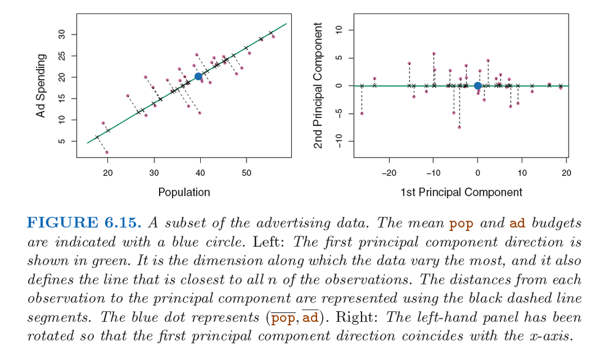

```python
Image(filename='img/Fig6.15.png')
```

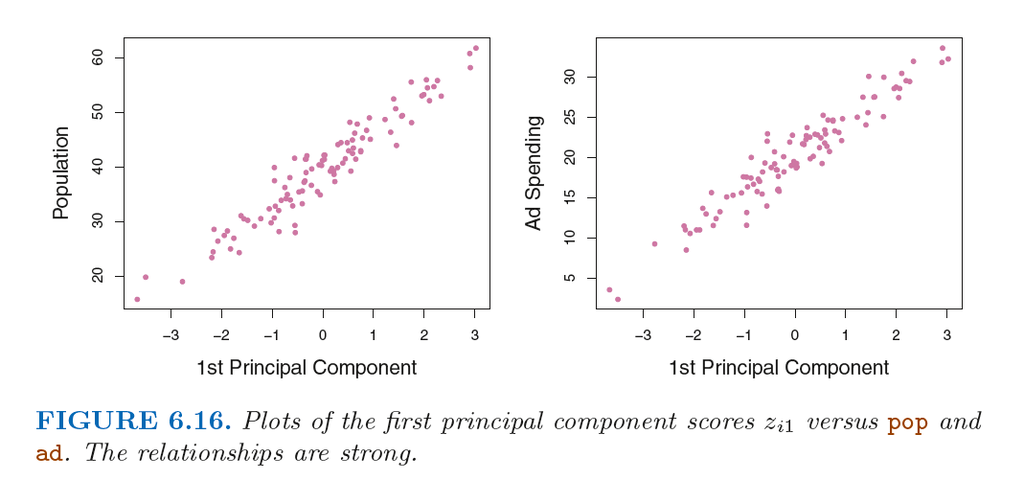

```python
Image(filename='img/Fig6.16.png')
```

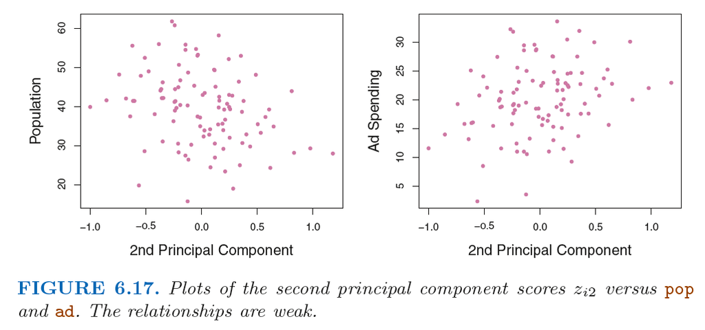

```python
Image(filename='img/Fig6.17.png')
```

### The Principal Components Regression Approach

**용어:**

- **principal components regression(PCR)**:
  - M개의 principal components $Z_{1}, ..., Z_{M}$을 predictor로 사용한 least squares linear regression
  - Why good? $X_{1}, ... X_{p}$의 variation이 가장 크게 나타나는 방향 $Z_j$들이 대체로 $Y$와 상관관계가 가장 큰 components들이다.
  - PCR 가정 하에 M개의 $Z_{1}, ..., Z_{M}$가 p개의 X predictors에 대한 정보를 거의 다 포함하면 overfitting을 완화해 X predictors를 모두 사용한 least squares model보다 성능이 더 좋을 수 있다.
  - p개의 X predictors에 대한 variation/정보를 충분히(sufficiently) 설명하는 components의 개수 M이 작을수록 PCR의 성능은 좋아진다(Figure 6.18, 6.19)
  - M=p인 경우 기본 모형과 같아진다 (least squares fit using all p predictors)
  - **주의** 각 $Z_{k}$는 모든 p개의 X predictors의 선형결합이기 때문에 X predictors를 모두 사용한다. 따라서 PCR은 변수를 제거하는 feature selection method와 다르다
  - ridge regression은 PCR의 continuous version이다 (lasso regression과 다르게 모든 변수 사용, ridge regression의 $\lambda$는 continuous, PCR의 M은 discrete)
    - $\lambda$가 증가할수록 MSE가 증가하고, M이 감소할수록 MSE증가한다. (Figure 6.20)

**최적의 PCR:**

- principal component를 구하기 전에 각 predictor에 대한 정규화도 필요하다. 이는 변수의 scale 단위가 클수록 variance가 클 것이며 이는 principal component 선택에 영향을 미칠 것이다.
- cross-validation error가 최소가 되는 component 개수 M을 선택한다. (Figure 6.20)

**PCR의 단점:Unsupervised dimension reduction**

- principal component $Z_{k}$는 response Y와 관계없이 X만 잘 설명하도록 도출
- response Y가 principal component의 선택을 supervise하지 않는다

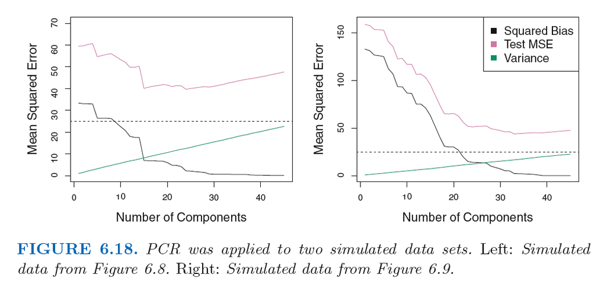

```python
Image(filename='img/Fig6.18.png')
```

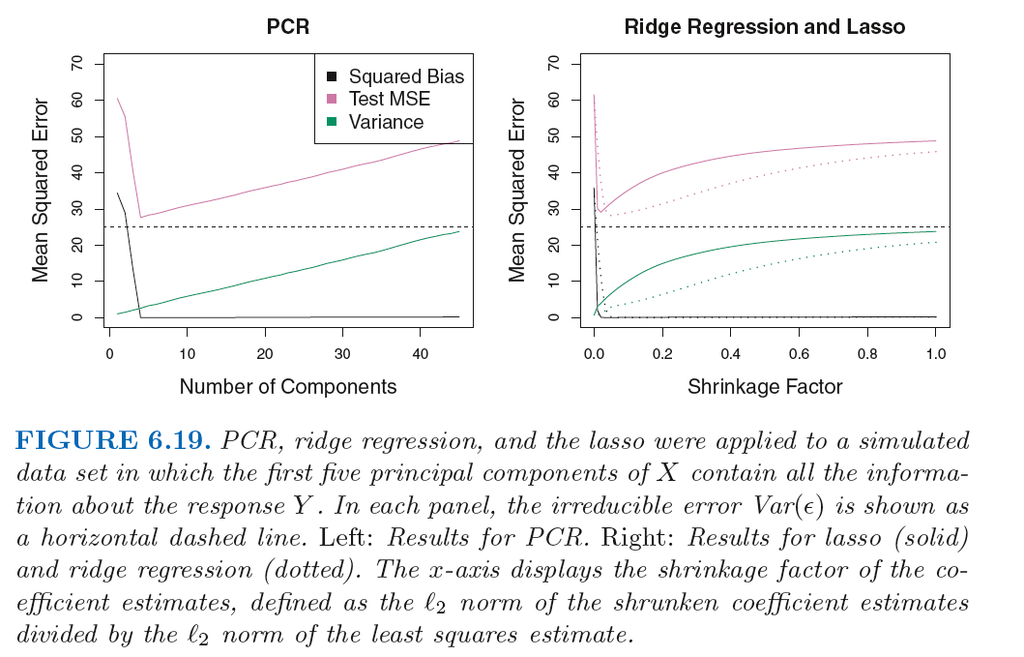

```python
Image(filename='img/Fig6.19.png')
```

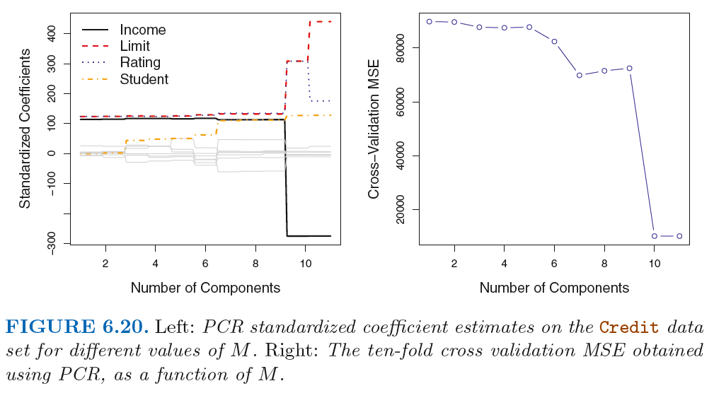

```python
Image(filename='img/Fig6.20.png')
```

### 6.3.2 Partial Least Squares

**용어:**

- **Partial Least Squares (PLS): supervised dimension reduction**
  - dimensions reduction: 기존 feature의 linear combinzation M개의 $Z_k$ 도출하고 이 M개의 feature들에 least squares linear regression 수행
  - Supervised: X뿐만 아니라 Y의 정보도 잘 포착하는 component/direction/$Z_k$ 선택
- **first PLS direction (도출방법)**
  1. p개의 predictor X 정규화
  2. 각 $X_{j}$를 Y에 대해 simple linear regression 수행하여 j개의 coefficient $\rho_j$
  3. first PLS= $Z_{1}$ = $\sum_{j=1}^{p}\phi_{j1}X_j$, where $\phi_{j1}=\rho_j$
     - PLS는 response와 가장 상관관계가 높은 변수에 가장 높은 weight를 부여 (예시 Fig.6.21)
- **kth PLS direction (k>1) (도출방법)**:
  1. 각 $X_{j}$를 $Z_{k-1}$에 대해 simple linear regression 수행하여 j개의 residuals $\epsilon_j$ 도출
  2. kth PLS= $Z_{k}$ = $\sum_{j=1}^{p}\phi_{jk}X_j$, where $\phi_{jk}=\epsilon_j$

**최적의 PLS:**

- 각 predictor에 대한 정규화도 필요하다.
- cross-validation error가 최소가 되는 component 개수 M을 선택한다.

**PLS의 단점:Unsupervised dimension reduction**

- ridge regression과 PCR에 비해 성능이 떨어진다
- bias를 줄일 수 있지만 variance를 상승시킬 수 있다.

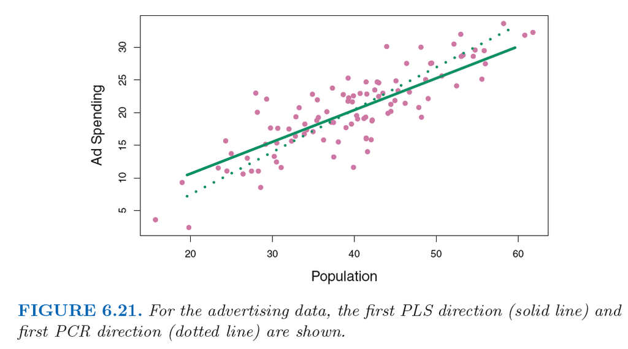

```python
Image(filename='img/Fig6.21.png')
```

## 6.4 Considerations in High Dimensions

## 6.4.1 High-Dimensional Data

- 최근 20년간 feature data의 개수가 폭발적으로 증가
- high-dimensional: $n<p$
  - feature와 response 간 상관관계 존재 여부와 무관하게 least squares 수행시 잔차가 0이 되어 perfect fit을 달성하는 계수를 구할 수 있음
  - 하지만 trainsing MSE가 0으로 수렴하더라도 test MSE는 증가
  - high-dimensional인 경우 $\hat{\sigma}^2$=0이기 때문에 $C_p$, AIC, BIC 방법론 사용 불가하며, fitting을 less flexible하게 만드는 (overfitting 방지) forward stepwise selection, ridge regression, lasso, PCR을 사용한다.
  - multicollinearity problem